# Chapter 6 homework

Author

Judah Altman

## Setup

```r
library(tidyverse)
library(here)
library(gssrdoc)
```

## Data

This homework uses a built-in dataset from base R (`state.x77`). Run the code below to create the working tibble `states`.

```r
state.x77_with_names <- as_tibble(state.x77,
                                  rownames = "state")

states <- bind_cols(state.x77_with_names,
                    region = state.division) |>
  janitor::clean_names() |>
  mutate(
    south = as.integer(
      str_detect(as.character(region), "South")
    )
  )

?state.x77
```

Throughout, use:

- outcome: `life_exp`
- predictor: `murder`

# Question 1: Descriptive statistics

## 1a. Descriptive statistics (psych)

Use `psych::describe()` (or something else if you want) to get descriptive statistics for `life_exp` and `murder`.

```r
glimpse(states)
```

```
Rows: 50
Columns: 11
$ state      <chr> "Alabama", "Alaska", "Arizona", "Arkansas", "California", "…
$ population <dbl> 3615, 365, 2212, 2110, 21198, 2541, 3100, 579, 8277, 4931, …
$ income     <dbl> 3624, 6315, 4530, 3378, 5114, 4884, 5348, 4809, 4815, 4091,…
$ illiteracy <dbl> 2.1, 1.5, 1.8, 1.9, 1.1, 0.7, 1.1, 0.9, 1.3, 2.0, 1.9, 0.6,…
$ life_exp   <dbl> 69.05, 69.31, 70.55, 70.66, 71.71, 72.06, 72.48, 70.06, 70.…
$ murder     <dbl> 15.1, 11.3, 7.8, 10.1, 10.3, 6.8, 3.1, 6.2, 10.7, 13.9, 6.2…
$ hs_grad    <dbl> 41.3, 66.7, 58.1, 39.9, 62.6, 63.9, 56.0, 54.6, 52.6, 40.6,…
$ frost      <dbl> 20, 152, 15, 65, 20, 166, 139, 103, 11, 60, 0, 126, 127, 12…
$ area       <dbl> 50708, 566432, 113417, 51945, 156361, 103766, 4862, 1982, 5…
$ region     <fct> East South Central, Pacific, Mountain, West South Central, …
$ south      <int> 1, 0, 0, 1, 0, 0, 0, 1, 1, 1, 0, 0, 0, 0, 0, 0, 1, 1, 0, 1,…
```

```r
psych::describe(states$life_exp)
```

```
   vars  n  mean   sd median trimmed  mad   min  max range  skew kurtosis   se
X1    1 50 70.88 1.34  70.67   70.92 1.54 67.96 73.6  5.64 -0.15    -0.67 0.19
```

```r
psych::describe(states$murder)
```

```
   vars  n mean   sd median trimmed  mad min  max range skew kurtosis   se
X1    1 50 7.38 3.69   6.85     7.3 5.19 1.4 15.1  13.7 0.13    -1.21 0.52
```

## 1b. Descriptive statistics (tidyverse)

Compute (at minimum) the mean and standard deviation of `life_exp` and `murder` using `summarize()`.

```r
states |>
  summarize(life_mean = mean(life_exp),
            murder_mean = mean(murder),
            life_sd = sd(life_exp),
            murder_sd = sd(murder))
```

```
# A tibble: 1 × 4
  life_mean murder_mean life_sd murder_sd
      <dbl>       <dbl>   <dbl>     <dbl>
1      70.9        7.38    1.34      3.69
```

# Question 2a: Regression and model comparison

You will evaluate whether `murder` predicts `life_exp`.

## 2a(i). Write the model comparison and null hypothesis

Write Model C and Model A in words and equations, and state the null hypothesis.

A typical setup for testing whether a slope is needed is:

- Model C (constrained): slope fixed at 0
- Model A (augmented): slope estimated from the data

Use the notation below (fill in the missing pieces in your write-up):

Model C: The average of life expectancy is the best predictor of life expectancy.
$$Y_i = b_0 + \varepsilon_i$$

Model A: Murder improves our predictions of life expectancy.
$$Y_i = b_0 + b_1X_i + \varepsilon_i$$

Null hypothesis (in symbols and words): Murder does not affect life expectancy.
$$H_0: b_1 = 0$$

## 2a(ii). Fit both models

```r
mc <- lm(life_exp ~ 1, data = states)
summary(mc)
```

```
Call:
lm(formula = life_exp ~ 1, data = states)

Residuals:
    Min      1Q  Median      3Q     Max
-2.9186 -0.7611 -0.2036  1.0139  2.7214

Coefficients:
            Estimate Std. Error t value Pr(>|t|)
(Intercept)  70.8786     0.1898   373.4   <2e-16 ***
---
Signif. codes:  0 '***' 0.001 '**' 0.01 '*' 0.05 '.' 0.1 ' ' 1

Residual standard error: 1.342 on 49 degrees of freedom
```

```r
ma <- lm(life_exp ~ 1 + murder, data = states)
summary(ma)
```

```
Call:
lm(formula = life_exp ~ 1 + murder, data = states)

Residuals:
     Min       1Q   Median       3Q      Max
-1.81690 -0.48139  0.09591  0.39769  2.38691

Coefficients:
            Estimate Std. Error t value Pr(>|t|)
(Intercept) 72.97356    0.26997  270.30  < 2e-16 ***
murder      -0.28395    0.03279   -8.66 2.26e-11 ***
---
Signif. codes:  0 '***' 0.001 '**' 0.01 '*' 0.05 '.' 0.1 ' ' 1

Residual standard error: 0.8473 on 48 degrees of freedom
Multiple R-squared:  0.6097,    Adjusted R-squared:  0.6016
F-statistic: 74.99 on 1 and 48 DF,  p-value: 2.26e-11
```

## 2a(iii). Compute SSE(C), SSE(A), PRE, and F

Compute:

- $\mathrm{SSE}_C$ and $\mathrm{SSE}_A$ from the fitted models
- $\mathrm{PRE} = (\mathrm{SSE}_C - \mathrm{SSE}_A)/\mathrm{SSE}_C$
- the model-comparison $F$ statistic

Use `deviance()` for SSE (RSS) and `df.residual()` as needed.

$$F = \frac{(\mathrm{SSE}_C - \mathrm{SSE}_A)/(P_A - P_C)}{\mathrm{SSE}_A/(n - P_A)}.$$

```r
sse_c <- deviance(mc)
sse_c
```

```
[1] 88.299
```

```r
sse_a <- deviance(ma)
sse_a
```

```
[1] 34.46133
```

```r
pre <- (sse_c - sse_a) / sse_c
pre
```

```
[1] 0.6097201
```

```r
f_star <- (sse_c - sse_a) / (sse_a / df.residual(ma))
f_star
```

```
[1] 74.98865
```

## 2a(iv). Write the prediction equation and interpret coefficients

Write the prediction equation implied by Model A:

$$\widehat{\text{life_exp}} = 72.97 - 0.28(\text{murder})$$

Interpret:

- the intercept: when the murder rate is 0 per 100,000 people, the average life expectancy in a state will be 72.97 years
- the slope: for every 1 per 100,00 people increase in murder rate in a state, that state’s life expectancy will decrease by 0.28 years.

## 2a(v). Conclusion

State:

- statistical conclusion (report $F$ or $t$, PRE, and $p$)

```r
f_crit <- qf(0.99, 1, 48)
f_crit < f_star
```

```
[1] TRUE
```

```r
t_star <- sqrt(f_star)
t_star
```

```
[1] 8.659599
```

We can reject the null hypothesis because the $F$ value is larger than its respective critical value when $\alpha = 0.01$

- substantive conclusion (in plain language)

Murder rate has a meaningful (statistically significant) effect on life expectancy, therefore we can reject the null hypothesis that murder rate does not affect the average life expectancy of a state.

# Question 2b: Center the predictor

Create a centered version of murder:

## 2b(i). Create `murder_c` and refit the model

```r
states <- states |>
  mutate(murder_c = murder - mean(murder))

mc_c <- lm(life_exp ~ 1, data = states)
summary(mc_c)
```

```
Call:
lm(formula = life_exp ~ 1, data = states)

Residuals:
    Min      1Q  Median      3Q     Max
-2.9186 -0.7611 -0.2036  1.0139  2.7214

Coefficients:
            Estimate Std. Error t value Pr(>|t|)
(Intercept)  70.8786     0.1898   373.4   <2e-16 ***
---
Signif. codes:  0 '***' 0.001 '**' 0.01 '*' 0.05 '.' 0.1 ' ' 1

Residual standard error: 1.342 on 49 degrees of freedom
```

```r
ma_c <- lm(life_exp ~ 1 + murder_c, data = states)
summary(ma_c)
```

```
Call:
lm(formula = life_exp ~ 1 + murder_c, data = states)

Residuals:
     Min       1Q   Median       3Q      Max
-1.81690 -0.48139  0.09591  0.39769  2.38691

Coefficients:
            Estimate Std. Error t value Pr(>|t|)
(Intercept) 70.87860    0.11983  591.50  < 2e-16 ***
murder_c    -0.28395    0.03279   -8.66 2.26e-11 ***
---
Signif. codes:  0 '***' 0.001 '**' 0.01 '*' 0.05 '.' 0.1 ' ' 1

Residual standard error: 0.8473 on 48 degrees of freedom
Multiple R-squared:  0.6097,    Adjusted R-squared:  0.6016
F-statistic: 74.99 on 1 and 48 DF,  p-value: 2.26e-11
```

## 2b(ii). Report SSE(A), SSE(C), PRE, and F again

Compute the same fit statistics (SSE, PRE, F). Compare them to the results from Question 2a.

```r
sse_c_c <- deviance(mc_c)
sse_c_c
```

```
[1] 88.299
```

```r
sse_c
```

```
[1] 88.299
```

```r
sse_a_c <- deviance(ma_c)
sse_a_c
```

```
[1] 34.46133
```

```r
sse_a
```

```
[1] 34.46133
```

```r
pre_c <- (sse_c_c - sse_a_c) / sse_c_c
pre_c
```

```
[1] 0.6097201
```

```r
pre
```

```
[1] 0.6097201
```

```r
f_star_c <- (sse_c_c - sse_a_c) / (sse_a_c / df.residual(ma_c))
f_star_c
```

```
[1] 74.98865
```

```r
f_star
```

```
[1] 74.98865
```

They are all the same from 2a.

## 2b(iii). Interpret coefficients after centering

Write the prediction equation for the centered model and interpret the intercept and slope.

$$\widehat{\text{life_exp}} = 70.88 - 0.28(\text{murder_c})$$

In particular: what does the intercept represent *now*?

- the intercept: when a state has the average murder rate per 100,000 people, the average life expectancy in a state will be 70.88 years
- the slope: for every 1 per 100,00 people increase in murder rate in a state above the average murder rate of all states, that state’s life expectancy will decrease by 0.28 years. Similarly, for every 1 per 100,00 people decrease in murder rate in a state below the average murder rate of all states, that state’s life expectancy will increase by 0.28 years.

## 2b(iv). Plot and compare

Make two scatterplots with regression lines:

1. `life_exp` vs. `murder`
2. `life_exp` vs. `murder_c`

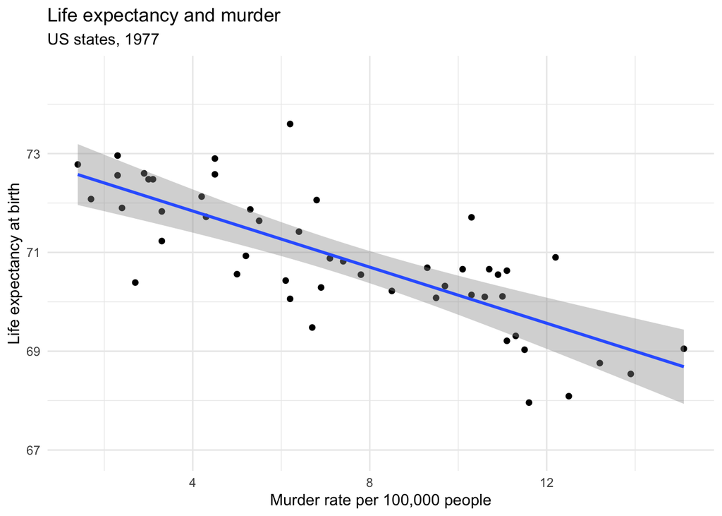

```r
ggplot(states, aes(x = murder, y = life_exp)) +
  geom_point() +
  geom_smooth(method = "lm", level = 0.99) +
  ylim(c(min(states$life_exp - 1), max(states$life_exp) + 1)) +
  labs(title = "Life expectancy and murder",
       subtitle = "US states, 1977",
       x = "Murder rate per 100,000 people",
       y = "Life expectancy at birth") +
  theme_minimal()
```

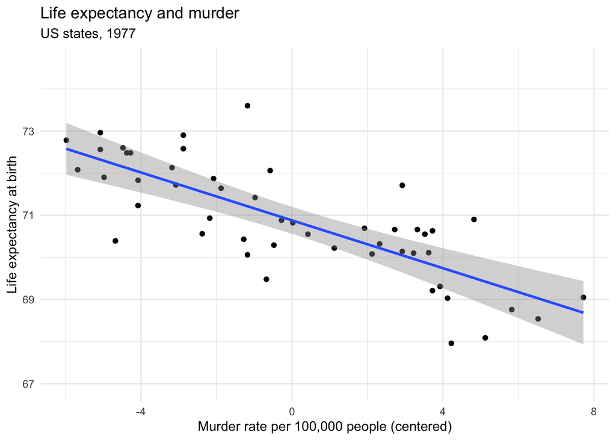

```r
ggplot(states, aes(x = murder_c, y = life_exp)) +
  geom_point() +
  geom_smooth(method = "lm", level = 0.99) +
  ylim(c(min(states$life_exp - 1), max(states$life_exp) + 1)) +
  labs(title = "Life expectancy and murder",
       subtitle = "US states, 1977",
       x = "Murder rate per 100,000 people (centered)",
       y = "Life expectancy at birth") +
  theme_minimal()
```

How are these plots different?

# Question 2c: Change the units of the predictor

Create a transformed predictor by standardizing `murder`.

## 2c(i). Create `murder_std` and refit the model

```r
states <- states |>
  mutate(murder_std = (murder - mean(murder)) / sd(murder))

mc_s <- lm(life_exp ~ 1, data = states)
summary(mc_s)
```

```
Call:
lm(formula = life_exp ~ 1, data = states)

Residuals:
    Min      1Q  Median      3Q     Max
-2.9186 -0.7611 -0.2036  1.0139  2.7214

Coefficients:
            Estimate Std. Error t value Pr(>|t|)
(Intercept)  70.8786     0.1898   373.4   <2e-16 ***
---
Signif. codes:  0 '***' 0.001 '**' 0.01 '*' 0.05 '.' 0.1 ' ' 1

Residual standard error: 1.342 on 49 degrees of freedom
```

```r
ma_s <- lm(life_exp ~ 1 + murder_std, data = states)
summary(ma_s)
```

```
Call:
lm(formula = life_exp ~ 1 + murder_std, data = states)

Residuals:
     Min       1Q   Median       3Q      Max
-1.81690 -0.48139  0.09591  0.39769  2.38691

Coefficients:
            Estimate Std. Error t value Pr(>|t|)
(Intercept)  70.8786     0.1198  591.50  < 2e-16 ***
murder_std   -1.0482     0.1210   -8.66 2.26e-11 ***
---
Signif. codes:  0 '***' 0.001 '**' 0.01 '*' 0.05 '.' 0.1 ' ' 1

Residual standard error: 0.8473 on 48 degrees of freedom
Multiple R-squared:  0.6097,    Adjusted R-squared:  0.6016
F-statistic: 74.99 on 1 and 48 DF,  p-value: 2.26e-11
```

## 2c(ii). Report SSE(A), SSE(C), PRE, and F again

Compute SSE, PRE, and F again and compare them to 2a and 2b.

```r
sse_c_s <- deviance(mc_s)
sse_c_s
```

```
[1] 88.299
```

```r
sse_c_c
```

```
[1] 88.299
```

```r
sse_c
```

```
[1] 88.299
```

```r
sse_a_s <- deviance(ma_s)
sse_a_s
```

```
[1] 34.46133
```

```r
sse_a_c
```

```
[1] 34.46133
```

```r
sse_a
```

```
[1] 34.46133
```

```r
pre_s <- (sse_c_s - sse_a_s) / sse_c_s
pre_s
```

```
[1] 0.6097201
```

```r
pre_c
```

```
[1] 0.6097201
```

```r
pre
```

```
[1] 0.6097201
```

```r
f_star_s <- (sse_c_s - sse_a_s) / (sse_a_s / df.residual(ma_s))
f_star_s
```

```
[1] 74.98865
```

```r
f_star_c
```

```
[1] 74.98865
```

```r
f_star
```

```
[1] 74.98865
```

## 2c(iii). Interpret coefficients after rescaling

Write the prediction equation and interpret the slope carefully in the new units.

$$\widehat{\text{life_exp}} = 70.88 - 1.05(\text{murder_std})$$

- the intercept: when a state has the average murder rate per 100,000 people, the average life expectancy in a state will be 70.88 years
- the slope: for every one standard deviation increase in murder rate in a state above the average murder rate of all states, that state’s life expectancy will decrease by 1.05 years. Similarly, for every 1 standard deviation decrease in murder rate in a state below the average murder rate of all states, that state’s life expectancy will increase by 1.05 years.

# Question 3: Predicted values and what transformations do (and do not) change

You now have three versions of the same basic relationship:

1. using `murder`
2. using `murder_c`
3. using `murder_std`

## 3a. Predicted life expectancy at a specific murder rate

Using each of your three fitted Model A versions, compute the predicted life expectancy for a state with `murder` = 8.

Show your work. (Be explicit about how you convert 8 into the appropriate value for `murder_c` and `murder_std`.)

```r
x = 8
y = 72.97 - 0.28*x
y
```

```
[1] 70.73
```

```r
x_c = x - mean(states$murder)
y_c = 70.88 - 0.28*x_c
y_c
```

```
[1] 70.70584
```

```r
x_s = (x - mean(states$murder)) / sd(states$murder)
y_s = 70.88 - 1.05*x_s
y_s
```

```
[1] 70.70308
```

```r
predict(ma)[8]
```

```
       8
71.21309
```

```r
predict(ma_c)[8]
```

```
       8
71.21309
```

```r
predict(ma_s)[8]
```

```
       8
71.21309
```

## 3b. Summary paragraph

Write a brief summary explaining what you learned about transforming a predictor:

- How do these transformations affect the estimated intercept and slope?

Transforming the predictor to centered changes the intercept but not the slope, transforming the predictor to standardized changes the intercept and the slope, but the intercept is the same as the centered intercept

- Do they change predicted values (when transformed consistently)?

- Do they change overall goodness of fit (SSE, PRE, $F$)?

No, goodness of fit is the same every time for all the values.

# Project application

Do the same thing with an outcome and predictor of your choice from your own dataset. Use three transformations:

- original
- normalized X
- fully standardized

Interpret the intercepts and slopes for each of the three models. Compare the fit statistics for each of the three models.

*My original data are not continuous variables so I switched to continuous variables.

```r
gss2024 <- readRDS(here("data", "gss2024.rds"))

df <- gss2024 |>
  select(coninc, hrs1) |>
  drop_na() |>
  haven::zap_labels()
```

Fitting the models (original, normalized X, fully standardized)

```r
df <- df |>
  mutate(coninc_std = (coninc - mean(coninc)) / sd(coninc),
         hrs1_std = (hrs1 - mean(hrs1)) / sd(hrs1),
         hrs1_norm = scales::rescale(hrs1))

mc <- lm(coninc ~ 1, data = df)
summary(mc)
```

```
Call:
lm(formula = coninc ~ 1, data = df)

Residuals:
   Min     1Q Median     3Q    Max
-55053 -30000  -8887  23485  83689

Coefficients:
            Estimate Std. Error t value Pr(>|t|)
(Intercept)    55335       1041   53.14   <2e-16 ***
---
Signif. codes:  0 '***' 0.001 '**' 0.01 '*' 0.05 '.' 0.1 ' ' 1

Residual standard error: 42040 on 1629 degrees of freedom
```

```r
mc_s <- lm(coninc_std ~ 1, data = df)
summary(mc_s)
```

```
Call:
lm(formula = coninc_std ~ 1, data = df)

Residuals:
    Min      1Q  Median      3Q     Max
-1.3095 -0.7136 -0.2114  0.5586  1.9906

Coefficients:
             Estimate Std. Error t value Pr(>|t|)
(Intercept) 1.215e-15  2.477e-02       0        1

Residual standard error: 1 on 1629 degrees of freedom
```

```r
ma <- lm(coninc ~ 1 + hrs1, data = df)
summary(ma)
```

```
Call:
lm(formula = coninc ~ 1 + hrs1, data = df)

Residuals:
   Min     1Q Median     3Q    Max
-81630 -30260 -13444  20938 104913

Coefficients:
            Estimate Std. Error t value Pr(>|t|)
(Intercept) 34111.26    3090.95  11.036  < 2e-16 ***
hrs1          537.08      73.79   7.278 5.24e-13 ***
---
Signif. codes:  0 '***' 0.001 '**' 0.01 '*' 0.05 '.' 0.1 ' ' 1

Residual standard error: 41390 on 1628 degrees of freedom
Multiple R-squared:  0.03151,   Adjusted R-squared:  0.03092
F-statistic: 52.97 on 1 and 1628 DF,  p-value: 5.236e-13
```

```r
ma_n <- lm(coninc ~ 1 + hrs1_norm, data = df)
summary(ma_n)
```

```
Call:
lm(formula = coninc ~ 1 + hrs1_norm, data = df)

Residuals:
   Min     1Q Median     3Q    Max
-81630 -30260 -13444  20938 104913

Coefficients:
            Estimate Std. Error t value Pr(>|t|)
(Intercept)    34111       3091  11.036  < 2e-16 ***
hrs1_norm      47800       6568   7.278 5.24e-13 ***
---
Signif. codes:  0 '***' 0.001 '**' 0.01 '*' 0.05 '.' 0.1 ' ' 1

Residual standard error: 41390 on 1628 degrees of freedom
Multiple R-squared:  0.03151,   Adjusted R-squared:  0.03092
F-statistic: 52.97 on 1 and 1628 DF,  p-value: 5.236e-13
```

```r
ma_s <- lm(coninc_std ~ 1 + hrs1_std, data = df)
summary(ma_s)
```

```
Call:
lm(formula = coninc_std ~ 1 + hrs1_std, data = df)

Residuals:
    Min      1Q  Median      3Q     Max
-1.9416 -0.7198 -0.3198  0.4980  2.4954

Coefficients:
             Estimate Std. Error t value Pr(>|t|)
(Intercept) 1.267e-15  2.438e-02   0.000        1
hrs1_std    1.775e-01  2.439e-02   7.278 5.24e-13 ***
---
Signif. codes:  0 '***' 0.001 '**' 0.01 '*' 0.05 '.' 0.1 ' ' 1

Residual standard error: 0.9844 on 1628 degrees of freedom
Multiple R-squared:  0.03151,   Adjusted R-squared:  0.03092
F-statistic: 52.97 on 1 and 1628 DF,  p-value: 5.236e-13
```

Original Model:

- intercept: If an individual worked zero hours last week, their family income will be predicted to be $34111.26
- slope: For every additional hour an individual worked last week, their family income will increase by 537.08 constant dollars

Normalized X Model:

- intercept: 34111 dollars is the predicted family income of an individual when an individual’s hours worked is at the minimum number of hours worked in the sample.
- slope: 47800 dollars is the amount that family income would be predicted to increase if the individuals worked the maximum possible number of hours in the sample.

Fully Standardized Model:

- intercept: 0 because the means of x and y in simple regression will always converge, so the average family income in standard units will when the individual works the average number of hours in standard units.
- slope: For every additional standard hour worked by an individual last week, their family income will be predicted to increase by 0.18 standard unit dollars.

Fit statistics

```r
sse_c <- deviance(mc)
sse_c
```

```
[1] 2.879294e+12
```

```r
sse_c_s <- deviance(mc_s)
sse_c_s
```

```
[1] 1629
```

```r
sse_a <- deviance(ma)
sse_a_n <- deviance(ma_n)
sse_a_s <- deviance(ma_s)
sse_a
```

```
[1] 2.788557e+12
```

```r
sse_a_n
```

```
[1] 2.788557e+12
```

```r
sse_a_s
```

```
[1] 1577.664
```

```r
pre <- (sse_c - sse_a) / sse_c
pre_n <- (sse_c - sse_a_n) / sse_c
pre_s <- (sse_c_s - sse_a_s) / sse_c_s
pre
```

```
[1] 0.03151378
```

```r
pre_n
```

```
[1] 0.03151378
```

```r
pre_s
```

```
[1] 0.03151378
```

```r
f_star <- (sse_c - sse_a) / (sse_a / df.residual(ma))
f_star_n <- (sse_c - sse_a_n) / (sse_a_n / df.residual(ma_n))
f_star_s <- (sse_c_s - sse_a_s) / (sse_a_s / df.residual(ma_s))
f_star
```

```
[1] 52.97384
```

```r
f_star_n
```

```
[1] 52.97384
```

```r
f_star_s
```

```
[1] 52.97384
```

All the same (except standardized SSE’s which reduce error in standardized units)